# **Milestone 1**

### **Bivariate Analysis: BAD vs Categorical Variables**

**The stacked bar chart (aka stacked bar graph)** extends the standard bar chart from looking at numeric values across one categorical variable to two.

```python
### Function to plot stacked bar charts for categorical columns

def stacked_plot(x):

    tab1 = pd.crosstab(x,data['BAD'],margins=True)
    print(tab1)
    print('-'*120)
    tab = pd.crosstab(x,data['BAD'],normalize='index')
    tab.plot(kind='bar',stacked=True,figsize=(10,5))
    plt.legend(loc='lower left', frameon=False)
    plt.legend(loc="upper left", bbox_to_anchor=(1,1))
    plt.xticks(rotation=45)
    plt.ylabel('Percentage Default %')
    plt.show()
```

```
BAD         0     1   All
REASON
DebtCon  3183   745  3928
HomeImp  1384   396  1780
All      4567  1141  5708
------------------------------------------------------------------------------------------------------------------------
```

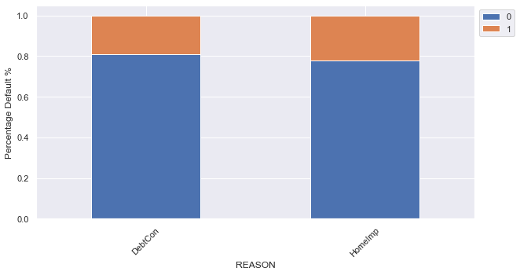

```python
# Plot stacked bar plot for BAD and REASON
stacked_plot(data['REASON'])
```

**Insights**

- The borrowers with the loan request reason of Home Improvement has a slightly higher default rate (over 20%) compared with the borrower who borrowed for debt consolidation (under 20%)

#### **Note:** As shown above, perform Bivariate Analysis on different pairs of Categorical vs BAD

```
BAD         0     1   All
JOB
Mgr       588   179   767
Office    823   125   948
Other    1834   554  2388
ProfExe  1064   212  1276
Sales      71    38   109
Self      135    58   193
All      4515  1166  5681
------------------------------------------------------------------------------------------------------------------------
```

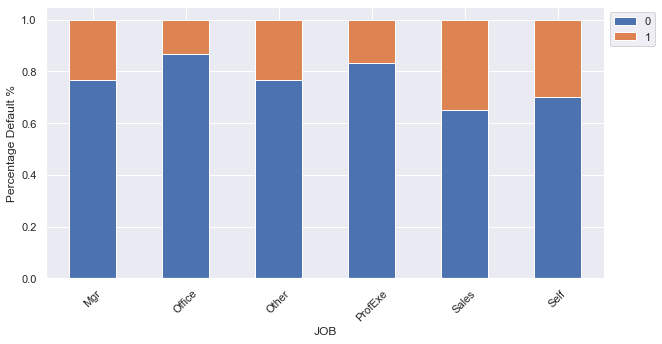

```python
# Plot stacked bar plot for BAD and REASON
stacked_plot(data['JOB'])
```

**Insights**

- Borrowers with Sales job type has the highest default rate, followed by "Self".
- Borrowers with Office job or ProfExe jobs have lowest default rates.

```
BAD       0     1   All
DEROG
0.0    3773   754  4527
1.0     266   169   435
2.0      78    82   160
3.0      15    43    58
4.0       5    18    23
5.0       8     7    15
6.0       5    10    15
7.0       0     8     8
8.0       0     6     6
9.0       0     3     3
10.0      0     2     2
All    4150  1102  5252
------------------------------------------------------------------------------------------------------------------------
```

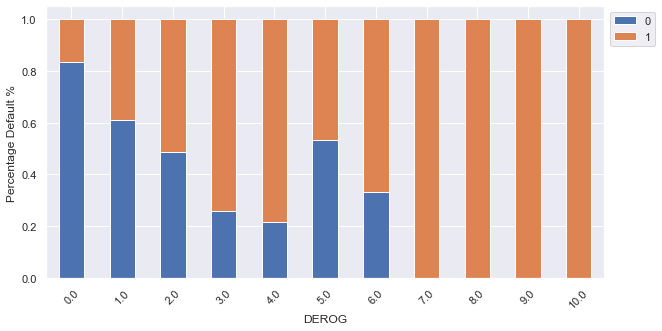

```python
# plot stacked bar plot for BAD and DEROG (categorical data as there are a finite amount of numbers of data categories)
stacked_plot(data['DEROG'])
```

**Insights**

```
BAD        0     1   All
DELINQ
0.0     3596   583  4179
1.0      432   222   654
2.0      138   112   250
3.0       58    71   129
4.0       32    46    78
5.0        7    31    38
6.0        0    27    27
7.0        0    13    13
8.0        0     5     5
10.0       0     2     2
11.0       0     2     2
12.0       0     1     1
13.0       0     1     1
15.0       0     1     1
All     4263  1117  5380
------------------------------------------------------------------------------------------------------------------------
```

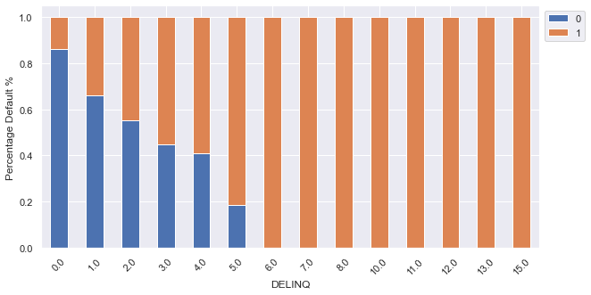

```python
stacked_plot(data.DELINQ)
```

**Insights**

- Customers whose DELINQ is more than 3 have very high chances (>50%) of defaulting.

### **Multivariate Analysis**

#### Analyze Correlation Heatmap for Numerical Variables

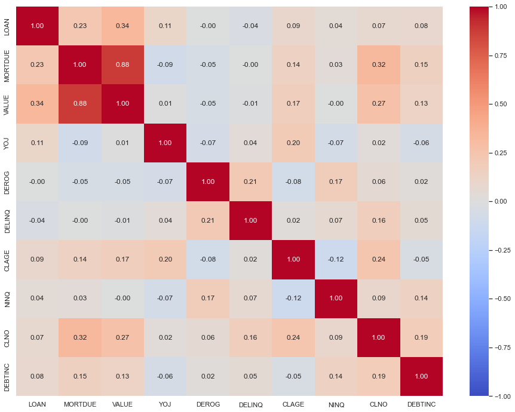

```python
# Separating numerical variables
numerical_col = data.select_dtypes(include=np.number).columns.tolist()

# Build correlation matrix for numerical columns

corr = data[numerical_col].corr()

# plot the heatmap

plt.figure(figsize=(16,12))
sns.heatmap(corr,cmap='coolwarm',vmax=1,vmin=-1,
        fmt=".2f", annot=True,
        xticklabels=corr.columns,
        yticklabels=corr.columns);
```

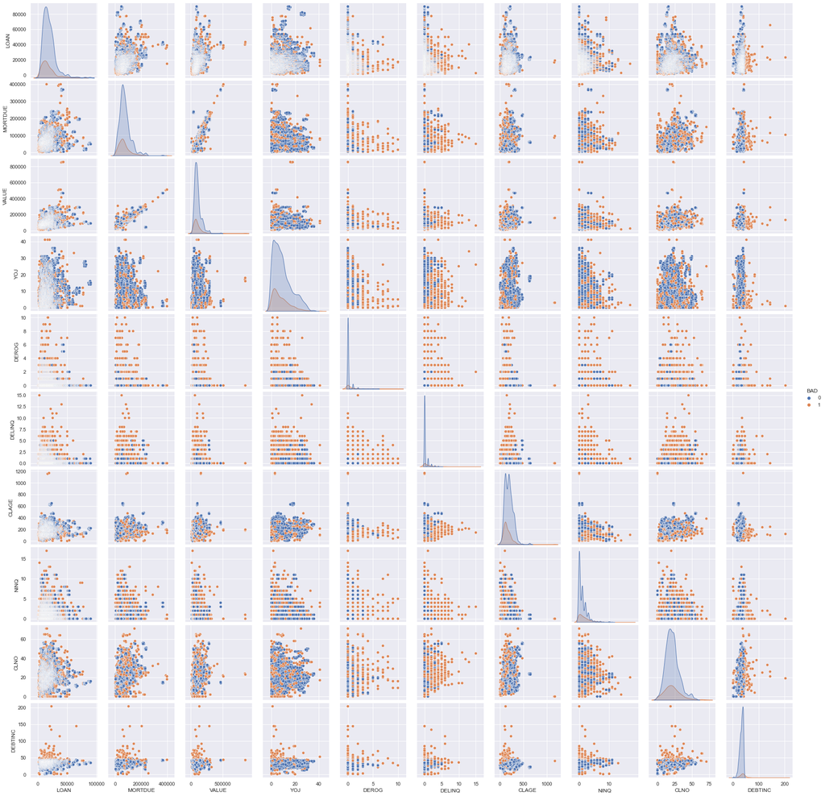

```python
# Build pairplot for the data with hue = 'BAD'
sns.pairplot(data=data, vars=numerical_col, hue='BAD')
```

### **Think about it**

- Are there missing values and outliers in the dataset? If yes, how can you treat them?
- Can you think of different ways in which this can be done and when to treat these outliers or not?
- Can we create new features based on Missing values?

#### Treating Outliers

```python
def treat_outliers(df,col):
    '''
    treats outliers in a varaible
    col: str, name of the numerical varaible
    df: data frame
    col: name of the column
    '''

    Q1=np.quantile(df[col], 0.25)# 25th quantile
    Q3=np.quantile(df[col], 0.75) # 75th quantile
    IQR=Q3-Q1  # IQR Range
    Lower_Whisker = Q1-1.5*IQR #define lower whisker
    Upper_Whisker = Q3+1.5*IQR  # define upper Whisker
    df[col] = np.clip(df[col], Lower_Whisker, Upper_Whisker) # all the values samller than Lower_Whisker will be assigned value of Lower_whisker
                                                            # and all the values above upper_whishker will be assigned value of upper_Whisker
    return df

def treat_outliers_all(df, col_list):
    '''
    treat outlier in all numerical varaibles
    col_list: list of numerical varaibles
    df: data frame
    '''
    for c in col_list:
        df = treat_outliers(df,c)

    return df
```

```python
df_raw = data.copy()

numerical_col = df_raw.select_dtypes(include=np.number).columns.tolist()# getting list of numerical columns

df = treat_outliers_all(df_raw,numerical_col)
```

#### Adding new columns in the dataset for each column which has missing values

```python
#For each column we create a binary flag for the row, if there is missing value in the row, then 1 else 0.
# important information for the business if certain field is missing
def add_binary_flag(df,col):
    '''
    df: It is the dataframe
    col: it is column which has missing values
    It returns a dataframe which has binary flag for missing values in column col
    '''
    new_col = str(col)
    new_col += '_missing_values_flag'
    df[new_col] = df[col].isna()
    return df
```

```python
# list of columns that has missing values in it
missing_col = [col for col in df.columns if df[col].isnull().any()]

for colmn in missing_col:
    add_binary_flag(df,colmn)
```

```python
df
```

|  | BAD | LOAN | MORTDUE | VALUE | REASON | JOB | YOJ | DEROG | DELINQ | CLAGE | ... | VALUE_missing_values_flag | REASON_missing_values_flag | JOB_missing_values_flag | YOJ_missing_values_flag | DEROG_missing_values_flag | DELINQ_missing_values_flag | CLAGE_missing_values_flag | NINQ_missing_values_flag | CLNO_missing_values_flag | DEBTINC_missing_values_flag |
| --- | --- | --- | --- | --- | --- | --- | --- | --- | --- | --- | --- | --- | --- | --- | --- | --- | --- | --- | --- | --- | --- |
| 0 | 1 | 1100.0 | 25860.0 | 39025.0 | HomeImp | Other | 10.5 | 0.0 | 0.0 | 94.366667 | ... | False | False | False | False | False | False | False | False | False | True |
| 1 | 1 | 1300.0 | 70053.0 | 68400.0 | HomeImp | Other | 7.0 | 0.0 | 2.0 | 121.833333 | ... | False | False | False | False | False | False | False | False | False | True |
| 2 | 1 | 1500.0 | 13500.0 | 16700.0 | HomeImp | Other | 4.0 | 0.0 | 0.0 | 149.466667 | ... | False | False | False | False | False | False | False | False | False | True |
| 3 | 1 | 1500.0 | NaN | NaN | NaN | NaN | NaN | NaN | NaN | NaN | ... | True | True | True | True | True | True | True | True | True | True |
| 4 | 0 | 1700.0 | 97800.0 | 112000.0 | HomeImp | Office | 3.0 | 0.0 | 0.0 | 93.333333 | ... | False | False | False | False | False | False | False | False | False | True |
| ... | ... | ... | ... | ... | ... | ... | ... | ... | ... | ... | ... | ... | ... | ... | ... | ... | ... | ... | ... | ... | ... |
| 5955 | 0 | 41600.0 | 57264.0 | 90185.0 | DebtCon | Other | 16.0 | 0.0 | 0.0 | 221.808718 | ... | False | False | False | False | False | False | False | False | False | False |
| 5956 | 0 | 41600.0 | 54576.0 | 92937.0 | DebtCon | Other | 16.0 | 0.0 | 0.0 | 208.692070 | ... | False | False | False | False | False | False | False | False | False | False |
| 5957 | 0 | 41600.0 | 54045.0 | 92924.0 | DebtCon | Other | 15.0 | 0.0 | 0.0 | 212.279697 | ... | False | False | False | False | False | False | False | False | False | False |
| 5958 | 0 | 41600.0 | 50370.0 | 91861.0 | DebtCon | Other | 14.0 | 0.0 | 0.0 | 213.892709 | ... | False | False | False | False | False | False | False | False | False | False |
| 5959 | 0 | 41600.0 | 48811.0 | 88934.0 | DebtCon | Other | 15.0 | 0.0 | 0.0 | 219.601002 | ... | False | False | False | False | False | False | False | False | False | False |

5960 rows × 24 columns

#### Filling missing values in numerical columns with median and mode in categorical variables

```python
#  Treat Missing values in numerical columns with median and mode in categorical variables
# Select numeric columns.
num_data = df.select_dtypes('number')

# Select string and object columns.
cat_data = df.select_dtypes('category').columns.tolist()#df.select_dtypes('object')
```

```python
# Fill numeric columns with median.
# Remove _________ and complete the code
for col in num_data.columns:
    median=df[col].median()
    df[col].fillna(median, inplace=True)
```

```python
# Fill object columns with mode.
# Remove _________ and complete the code
for column in cat_data:
    mode = df[column].mode()[0]
    df[column].fillna(mode, inplace=True)
```

```python
df
```

|  | BAD | LOAN | MORTDUE | VALUE | REASON | JOB | YOJ | DEROG | DELINQ | CLAGE | ... | VALUE_missing_values_flag | REASON_missing_values_flag | JOB_missing_values_flag | YOJ_missing_values_flag | DEROG_missing_values_flag | DELINQ_missing_values_flag | CLAGE_missing_values_flag | NINQ_missing_values_flag | CLNO_missing_values_flag | DEBTINC_missing_values_flag |
| --- | --- | --- | --- | --- | --- | --- | --- | --- | --- | --- | --- | --- | --- | --- | --- | --- | --- | --- | --- | --- | --- |
| 0 | 1 | 1100.0 | 25860.0 | 39025.0 | HomeImp | Other | 10.5 | 0.0 | 0.0 | 94.366667 | ... | False | False | False | False | False | False | False | False | False | True |
| 1 | 1 | 1300.0 | 70053.0 | 68400.0 | HomeImp | Other | 7.0 | 0.0 | 2.0 | 121.833333 | ... | False | False | False | False | False | False | False | False | False | True |
| 2 | 1 | 1500.0 | 13500.0 | 16700.0 | HomeImp | Other | 4.0 | 0.0 | 0.0 | 149.466667 | ... | False | False | False | False | False | False | False | False | False | True |
| 3 | 1 | 1500.0 | 65019.0 | 89235.5 | DebtCon | Other | 7.0 | 0.0 | 0.0 | 173.466667 | ... | True | True | True | True | True | True | True | True | True | True |
| 4 | 0 | 1700.0 | 97800.0 | 112000.0 | HomeImp | Office | 3.0 | 0.0 | 0.0 | 93.333333 | ... | False | False | False | False | False | False | False | False | False | True |
| ... | ... | ... | ... | ... | ... | ... | ... | ... | ... | ... | ... | ... | ... | ... | ... | ... | ... | ... | ... | ... | ... |
| 5955 | 0 | 41600.0 | 57264.0 | 90185.0 | DebtCon | Other | 16.0 | 0.0 | 0.0 | 221.808718 | ... | False | False | False | False | False | False | False | False | False | False |
| 5956 | 0 | 41600.0 | 54576.0 | 92937.0 | DebtCon | Other | 16.0 | 0.0 | 0.0 | 208.692070 | ... | False | False | False | False | False | False | False | False | False | False |
| 5957 | 0 | 41600.0 | 54045.0 | 92924.0 | DebtCon | Other | 15.0 | 0.0 | 0.0 | 212.279697 | ... | False | False | False | False | False | False | False | False | False | False |
| 5958 | 0 | 41600.0 | 50370.0 | 91861.0 | DebtCon | Other | 14.0 | 0.0 | 0.0 | 213.892709 | ... | False | False | False | False | False | False | False | False | False | False |
| 5959 | 0 | 41600.0 | 48811.0 | 88934.0 | DebtCon | Other | 15.0 | 0.0 | 0.0 | 219.601002 | ... | False | False | False | False | False | False | False | False | False | False |

5960 rows × 24 columns

```python
df.isnull().sum()
```

```
BAD                            0
LOAN                           0
MORTDUE                        0
VALUE                          0
REASON                         0
JOB                            0
YOJ                            0
DEROG                          0
DELINQ                         0
CLAGE                          0
NINQ                           0
CLNO                           0
DEBTINC                        0
MORTDUE_missing_values_flag    0
VALUE_missing_values_flag      0
REASON_missing_values_flag     0
JOB_missing_values_flag        0
YOJ_missing_values_flag        0
DEROG_missing_values_flag      0
DELINQ_missing_values_flag     0
CLAGE_missing_values_flag      0
NINQ_missing_values_flag       0
CLNO_missing_values_flag       0
DEBTINC_missing_values_flag    0
dtype: int64
```

```python
# data to be used in the model notebook
df.to_csv('hmeq_m2.csv')
```